# Practical machine learning in R

Marek Paulik

November 1, 2020

## Load Data and libraries

```r
pml_training <- read.csv("C:/Users/Marek/Documents/R/pml-training.csv")
testing <- read.csv("C:/Users/Marek/Documents/R/pml-testing.csv")
library(ggplot2)
library(dplyr)
library(caret)
library(naniar)
library(doSNOW)
library(randomForest)
```

## Exploratory analysis and preprocessing

# Data partition

We create a trainnig and validation set.

```r
inTrain <- createDataPartition(pml_training$classe, p=0.7, list = FALSE)
training <- pml_training[inTrain,]
validation <- pml_training[-inTrain,]
```

Dimensions of train, validation and test set.

```r
dim(training)
```

```
[1] 13737   160
```

```r
dim(validation)
```

```
[1] 5885  160
```

```r
dim(testing)
```

```
[1]  20 160
```

100 of variables have just around 600 obserations filled, otherwise they are blank or N/A. I remove all these variables. Furthermore, I remove first 5 columns which are not essential for prediction of the variable classe.

```r
training <- training %>%
        replace_with_na_all(condition = ~.x=="")

missing_count <- training %>%
        summarise_all(funs(sum(is.na(.))))
missing_count <- as.vector(missing_count==0)
training <- training[,missing_count]

training <- training[,6:60]
```

I do the same processing for validation set.

```r
validation <- validation %>%
        replace_with_na_all(condition = ~.x=="")

missing_count <- validation %>%
        summarise_all(funs(sum(is.na(.))))
missing_count <- as.vector(missing_count==0)
validation <- validation[,missing_count]

validation <- validation[,6:60]
validation$classe<- as.character(validation$classe)
validation$classe <-as.factor(validation$classe)
```

Check for colinearity in training set.

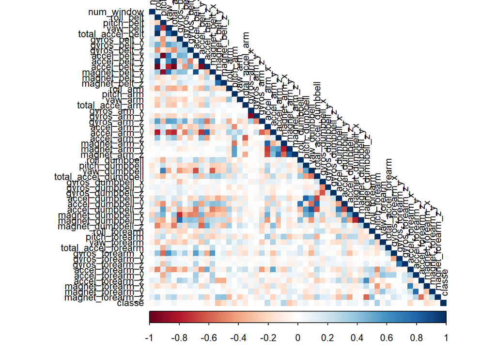

```r
library(corrplot)
corrMat <- cor(training[,-1])
corrplot(corrMat, method = "color", type = "lower", tl.cex = 0.8, tl.col = "black")
```

```r
training$classe<- as.character(training$classe)
training$classe <-as.factor(training$classe)

#fitControl <- trainControl(method = "repeatedcv", number=10,repeats=10)

modelrf <- randomForest(classe ~ ., data=training )
```

```r
modelrf
```

```
Call:
 randomForest(formula = classe ~ ., data = training)
               Type of random forest: classification
                     Number of trees: 500
No. of variables tried at each split: 7

        OOB estimate of  error rate: 0.29%
Confusion matrix:
     1    2    3    4    5 class.error
1 3906    0    0    0    0 0.000000000
2    5 2648    5    0    0 0.003762227
3    0    7 2388    1    0 0.003338898
4    0    0   16 2235    1 0.007548845
5    0    0    0    5 2520 0.001980198
```

Variable importance based on Gini index is also produced by random forest

```r
importance(modelrf)
```

```
                     MeanDecreaseGini
new_window                  0.5660425
num_window                931.4165612
roll_belt                 831.1922606
pitch_belt                459.9319489
yaw_belt                  576.1225034
total_accel_belt          155.1537683
gyros_belt_x               68.6234998
gyros_belt_y               75.8718797
gyros_belt_z              191.4832231
accel_belt_x               81.4377320
accel_belt_y               90.1329835
accel_belt_z              262.3218860
magnet_belt_x             160.0494606
magnet_belt_y             245.5575234
magnet_belt_z             247.9948731
roll_arm                  208.0095726
pitch_arm                 101.3331287
yaw_arm                   147.3039790
total_accel_arm            62.8952982
gyros_arm_x                80.0982840
gyros_arm_y                79.5079295
gyros_arm_z                35.7699024
accel_arm_x               153.3675958
accel_arm_y                98.0006051
accel_arm_z                81.9580243
magnet_arm_x              158.6456389
magnet_arm_y              141.3147465
magnet_arm_z              110.8032922
roll_dumbbell             289.2109141
pitch_dumbbell            120.3586947
yaw_dumbbell              168.1136614
total_accel_dumbbell      187.9236004
gyros_dumbbell_x           75.9563545
gyros_dumbbell_y          144.4045647
gyros_dumbbell_z           52.1357934
accel_dumbbell_x          153.8416454
accel_dumbbell_y          281.7853002
accel_dumbbell_z          210.3842908
magnet_dumbbell_x         329.3176648
magnet_dumbbell_y         437.6081507
magnet_dumbbell_z         493.2331857
roll_forearm              368.8141184
pitch_forearm             494.1324416
yaw_forearm               104.9805288
total_accel_forearm        59.1682926
gyros_forearm_x            48.3172684
gyros_forearm_y            74.4359676
gyros_forearm_z            48.2330393
accel_forearm_x           209.2747248
accel_forearm_y            90.5011397
accel_forearm_z           154.7377466
magnet_forearm_x          127.7112206
magnet_forearm_y          126.4584897
magnet_forearm_z          171.9203754
```

Now we produce confussion matrix to check the performance of our model on the validation set

```r
predict <- predict(modelrf, newdata=validation)
cfm <- confusionMatrix(predict,validation$classe)
cfm
```

```
Confusion Matrix and Statistics

          Reference
Prediction    1    2    3    4    5
         1 1673    3    0    0    0
         2    1 1136    0    0    0
         3    0    0 1026    4    0
         4    0    0    0  960    3
         5    0    0    0    0 1079

Overall Statistics

               Accuracy : 0.9981
                 95% CI : (0.9967, 0.9991)
    No Information Rate : 0.2845
    P-Value [Acc > NIR] : < 2.2e-16

                  Kappa : 0.9976

 Mcnemar's Test P-Value : NA

Statistics by Class:

                     Class: 1 Class: 2 Class: 3 Class: 4 Class: 5
Sensitivity            0.9994   0.9974   1.0000   0.9959   0.9972
Specificity            0.9993   0.9998   0.9992   0.9994   1.0000
Pos Pred Value         0.9982   0.9991   0.9961   0.9969   1.0000
Neg Pred Value         0.9998   0.9994   1.0000   0.9992   0.9994
Prevalence             0.2845   0.1935   0.1743   0.1638   0.1839
Detection Rate         0.2843   0.1930   0.1743   0.1631   0.1833
Detection Prevalence   0.2848   0.1932   0.1750   0.1636   0.1833
Balanced Accuracy      0.9993   0.9986   0.9996   0.9976   0.9986
```

## Model test

We need to do same transformation on test set as we did on training and validation set

```r
testing <- testing %>%
        replace_with_na_all(condition = ~.x=="")

missing_count <- testing %>%
        summarise_all(funs(sum(is.na(.))))
missing_count <- as.vector(missing_count==0)
testing <- testing[,missing_count]

testing <- testing[,6:60]
```

Predicting testing labels

```r
predict(modelrf,newdata=testing)
```

```
 1  2  3  4  5  6  7  8  9 10 11 12 13 14 15 16 17 18 19 20
 2  1  2  1  1  5  4  2  1  1  2  3  2  1  5  5  1  2  2  2
Levels: 1 2 3 4 5
```